# Bellabeat Case Study with R

Janice Lee

1/12/2022

##About Bellabeat Bellabeat is a high-tech manufacturer of health-focused products for women. It’s a successful company that has the potential to become a large player in the global smart device market. They collect data on activity, sleep, stress, and reproductive health to allow their users to learn about their personal health habits for effective change.

##Scenario You have been asked to focus on one of Bellabeat’s five products and analyze Fitbit data to gain insight into how non-Bellabeat consumers are using their smart devices. The insights you discover will then be presented to stakeholders such as Bellabeat’s co-founders, Urska Srsen and Sando Mur, as well as the marketing analytics team, to help guide marketing strategy.

##Questions for the analysis What are some trends in smart device usage? How could these trends apply to Bellabeat customers? How could these trends help influence Bellabeat marketing strategy?

##Load the csv files

```r
#downloading packages to use
library(tidyverse)
```

```r
library(tidyr)
library(dplyr)
library(ggplot2)
library(lubridate)
library(stringr)
library(janitor)
library(skimr)
library(here)
library(RColorBrewer)

#uploading all daily csv files
daily_activity <- read_csv("Desktop/dailyActivity_merged.csv")
daily_calories <- read_csv("Desktop/dailyCalories_merged.csv")
daily_intensities <- read_csv("Desktop/dailyIntensities_merged.csv")
daily_steps <- read_csv("Desktop/dailySteps_merged.csv")
sleep_day <- read_csv("Desktop/sleepDay_merged.csv")
weight_log <- read_csv("Desktop/weightLogInfo_merged.csv")
#view headers for all files
head(daily_activity)
```

```
## # A tibble: 6 × 15
##        Id ActivityDate TotalSteps TotalDistance TrackerDistance LoggedActivitie…
##     <dbl> <chr>             <dbl>         <dbl>           <dbl>            <dbl>
## 1  1.50e9 4/12/2016         13162          8.5             8.5                 0
## 2  1.50e9 4/13/2016         10735          6.97            6.97                0
## 3  1.50e9 4/14/2016         10460          6.74            6.74                0
## 4  1.50e9 4/15/2016          9762          6.28            6.28                0
## 5  1.50e9 4/16/2016         12669          8.16            8.16                0
## 6  1.50e9 4/17/2016          9705          6.48            6.48                0
## # … with 9 more variables: VeryActiveDistance <dbl>,
## #   ModeratelyActiveDistance <dbl>, LightActiveDistance <dbl>,
## #   SedentaryActiveDistance <dbl>, VeryActiveMinutes <dbl>,
## #   FairlyActiveMinutes <dbl>, LightlyActiveMinutes <dbl>,
## #   SedentaryMinutes <dbl>, Calories <dbl>
```

```r
head(daily_calories)
```

```
## # A tibble: 6 × 3
##           Id ActivityDay Calories
##        <dbl> <chr>          <dbl>
## 1 1503960366 4/12/2016       1985
## 2 1503960366 4/13/2016       1797
## 3 1503960366 4/14/2016       1776
## 4 1503960366 4/15/2016       1745
## 5 1503960366 4/16/2016       1863
## 6 1503960366 4/17/2016       1728
```

```r
head(daily_intensities)
```

```
## # A tibble: 6 × 10
##           Id ActivityDay SedentaryMinutes LightlyActiveMinutes FairlyActiveMinu…
##        <dbl> <chr>                  <dbl>                <dbl>             <dbl>
## 1 1503960366 4/12/2016                728                  328                13
## 2 1503960366 4/13/2016                776                  217                19
## 3 1503960366 4/14/2016               1218                  181                11
## 4 1503960366 4/15/2016                726                  209                34
## 5 1503960366 4/16/2016                773                  221                10
## 6 1503960366 4/17/2016                539                  164                20
## # … with 5 more variables: VeryActiveMinutes <dbl>,
## #   SedentaryActiveDistance <dbl>, LightActiveDistance <dbl>,
## #   ModeratelyActiveDistance <dbl>, VeryActiveDistance <dbl>
```

```r
head(daily_steps)
```

```
## # A tibble: 6 × 3
##           Id ActivityDay StepTotal
##        <dbl> <chr>           <dbl>
## 1 1503960366 4/12/2016       13162
## 2 1503960366 4/13/2016       10735
## 3 1503960366 4/14/2016       10460
## 4 1503960366 4/15/2016        9762
## 5 1503960366 4/16/2016       12669
## 6 1503960366 4/17/2016        9705
```

```r
head(sleep_day)
```

```
## # A tibble: 6 × 5
##           Id SleepDay          TotalSleepRecor… TotalMinutesAsle… TotalTimeInBed
##        <dbl> <chr>                        <dbl>             <dbl>          <dbl>
## 1 1503960366 4/12/2016 12:00:…                1               327            346
## 2 1503960366 4/13/2016 12:00:…                2               384            407
## 3 1503960366 4/15/2016 12:00:…                1               412            442
## 4 1503960366 4/16/2016 12:00:…                2               340            367
## 5 1503960366 4/17/2016 12:00:…                1               700            712
## 6 1503960366 4/19/2016 12:00:…                1               304            320
```

```r
head(weight_log)
```

```
## # A tibble: 6 × 8
##           Id Date      WeightKg WeightPounds   Fat   BMI IsManualReport    LogId
##        <dbl> <chr>        <dbl>        <dbl> <dbl> <dbl> <lgl>             <dbl>
## 1 1503960366 5/2/2016…     52.6         116.    22  22.6 TRUE            1.46e12
## 2 1503960366 5/3/2016…     52.6         116.    NA  22.6 TRUE            1.46e12
## 3 1927972279 4/13/201…    134.          294.    NA  47.5 FALSE           1.46e12
## 4 2873212765 4/21/201…     56.7         125.    NA  21.5 TRUE            1.46e12
## 5 2873212765 5/12/201…     57.3         126.    NA  21.7 TRUE            1.46e12
## 6 4319703577 4/17/201…     72.4         160.    25  27.5 TRUE            1.46e12
```

##Data Cleaning

```r
skim(sleep_day)
```

Data summary

| Name | sleep_day |
| --- | --- |
| Number of rows | 413 |
| Number of columns | 5 |
| _______________________ |  |
| Column type frequency: |  |
| character | 1 |
| numeric | 4 |
| ________________________ |  |
| Group variables | None |

**Variable type: character**

| skim_variable | n_missing | complete_rate | min | max | empty | n_unique | whitespace |
| --- | --- | --- | --- | --- | --- | --- | --- |
| SleepDay | 0 | 1 | 20 | 21 | 0 | 31 | 0 |

**Variable type: numeric**

| skim_variable | n_missing | complete_rate | mean | sd | p0 | p25 | p50 | p75 | p100 | hist |
| --- | --- | --- | --- | --- | --- | --- | --- | --- | --- | --- |
| Id | 0 | 1 | 5.000979e+09 | 2.06036e+09 | 1503960366 | 3977333714 | 4702921684 | 6962181067 | 8792009665 | ▆▆▇▅▃ |
| TotalSleepRecords | 0 | 1 | 1.120000e+00 | 3.50000e-01 | 1 | 1 | 1 | 1 | 3 | ▇▁▁▁▁ |
| TotalMinutesAsleep | 0 | 1 | 4.194700e+02 | 1.18340e+02 | 58 | 361 | 433 | 490 | 796 | ▁▂▇▃▁ |
| TotalTimeInBed | 0 | 1 | 4.586400e+02 | 1.27100e+02 | 61 | 403 | 463 | 526 | 961 | ▁▃▇▁▁ |

```r
View(sleep_day)
sleep_day_1 <-
sleep_day %>%
  separate(SleepDay, c("SleepDate", "SleepTime","AM/PM"), sep="([ ])") %>%
  unite(SleepTimes, 3:4, sep=" ", remove=FALSE)%>%
  mutate(SleepDate= as.Date(SleepDate, "%m/%d/%Y"))%>%
  mutate(SleepTime= parse_time(SleepTimes, "%H:%M:%S %p"))%>%
  distinct()
new_sleep_day<- subset(sleep_day_1, select = -c(3,5))
View(new_sleep_day)
head(new_sleep_day)
```

```
## # A tibble: 6 × 6
##         Id SleepDate  SleepTime TotalSleepRecor… TotalMinutesAsl… TotalTimeInBed
##      <dbl> <date>     <time>               <dbl>            <dbl>          <dbl>
## 1   1.50e9 2016-04-12 00'00"                   1              327            346
## 2   1.50e9 2016-04-13 00'00"                   2              384            407
## 3   1.50e9 2016-04-15 00'00"                   1              412            442
## 4   1.50e9 2016-04-16 00'00"                   2              340            367
## 5   1.50e9 2016-04-17 00'00"                   1              700            712
## 6   1.50e9 2016-04-19 00'00"                   1              304            320
```

```r
skim(weight_log)
```

Data summary

| Name | weight_log |
| --- | --- |
| Number of rows | 67 |
| Number of columns | 8 |
| _______________________ |  |
| Column type frequency: |  |
| character | 1 |
| logical | 1 |
| numeric | 6 |
| ________________________ |  |
| Group variables | None |

**Variable type: character**

| skim_variable | n_missing | complete_rate | min | max | empty | n_unique | whitespace |
| --- | --- | --- | --- | --- | --- | --- | --- |
| Date | 0 | 1 | 19 | 21 | 0 | 56 | 0 |

**Variable type: logical**

| skim_variable | n_missing | complete_rate | mean | count |
| --- | --- | --- | --- | --- |
| IsManualReport | 0 | 1 | 0.61 | TRU: 41, FAL: 26 |

**Variable type: numeric**

| skim_variable | n_missing | complete_rate | mean | sd | p0 | p25 | p50 | p75 | p100 | hist |
| --- | --- | --- | --- | --- | --- | --- | --- | --- | --- | --- |
| Id | 0 | 1.00 | 7.009282e+09 | 1.950322e+09 | 1.503960e+09 | 6.962181e+09 | 6.962181e+09 | 8.877689e+09 | 8.877689e+09 | ▁▁▂▇▆ |
| WeightKg | 0 | 1.00 | 7.204000e+01 | 1.392000e+01 | 5.260000e+01 | 6.140000e+01 | 6.250000e+01 | 8.505000e+01 | 1.335000e+02 | ▇▃▃▁▁ |
| WeightPounds | 0 | 1.00 | 1.588100e+02 | 3.070000e+01 | 1.159600e+02 | 1.353600e+02 | 1.377900e+02 | 1.875000e+02 | 2.943200e+02 | ▇▃▃▁▁ |
| Fat | 65 | 0.03 | 2.350000e+01 | 2.120000e+00 | 2.200000e+01 | 2.275000e+01 | 2.350000e+01 | 2.425000e+01 | 2.500000e+01 | ▇▁▁▁▇ |
| BMI | 0 | 1.00 | 2.519000e+01 | 3.070000e+00 | 2.145000e+01 | 2.396000e+01 | 2.439000e+01 | 2.556000e+01 | 4.754000e+01 | ▇▁▁▁▁ |
| LogId | 0 | 1.00 | 1.461772e+12 | 7.829948e+08 | 1.460444e+12 | 1.461079e+12 | 1.461802e+12 | 1.462375e+12 | 1.463098e+12 | ▇▇▆▇▇ |

```r
View(weight_log)
weight_log_1<-
weight_log %>% separate(Date, c("LogDate", "LogTime","AM/PM"), sep="([ ])")%>%
  unite(LogTimes, 3:4, sep=" ", remove=FALSE)%>%
  mutate(LogDate= as.Date(LogDate, "%m/%d/%Y"))%>%
  mutate(LogTime= parse_time(LogTimes, "%H:%M:%S %p"))%>%
  distinct()
weight_log_1= weight_log_1[,!sapply(weight_log_1, function(x) mean(is.na(x)))>0.5]
new_weight_log<- subset(weight_log_1, select = -c(3,5))
View(new_weight_log)
head(new_weight_log)
```

```
## # A tibble: 6 × 8
##        Id LogDate    LogTime  WeightKg WeightPounds   BMI IsManualReport   LogId
##     <dbl> <date>     <time>      <dbl>        <dbl> <dbl> <lgl>            <dbl>
## 1  1.50e9 2016-05-02 23:59:59     52.6         116.  22.6 TRUE           1.46e12
## 2  1.50e9 2016-05-03 23:59:59     52.6         116.  22.6 TRUE           1.46e12
## 3  1.93e9 2016-04-13 01:08:52    134.          294.  47.5 FALSE          1.46e12
## 4  2.87e9 2016-04-21 23:59:59     56.7         125.  21.5 TRUE           1.46e12
## 5  2.87e9 2016-05-12 23:59:59     57.3         126.  21.7 TRUE           1.46e12
## 6  4.32e9 2016-04-17 23:59:59     72.4         160.  27.5 TRUE           1.46e12
```

```r
colnames(daily_activity)[2] <-"ActivityDay"
colnames(daily_steps)[3] <- "TotalSteps"
```

After checking their headers, I can see that dates for sleep_day and weight_log are in character format not date format so I fix this. I also check for duplicates and missing information. I found 3 duplicate rows in the sleep_day dataset and deleted them. I also found that 65 of 67 rows are empty in the Fat column under the weight_log dataset so decided to get rid of the column completely by using a formula that gets rid of columns where more than 50% of entries are empty/NA. I also clean up the names in daily_activity and daily_steps to make columns match up when merging sets of data together.

##Data Prep

```r
#let's see how many unique participants are there for each activity
n_distinct(daily_activity$Id)
```

```
## [1] 33
```

```r
n_distinct(daily_calories$Id)
```

```
## [1] 33
```

```r
n_distinct(daily_intensities$Id)
```

```
## [1] 33
```

```r
n_distinct(daily_steps$Id)
```

```
## [1] 33
```

```r
n_distinct(new_sleep_day$Id)
```

```
## [1] 24
```

```r
n_distinct(new_weight_log$Id)
```

```
## [1] 8
```

```r
#I found that most people use their Fitbit device to track daily activities(33), intensities(33), calories(33), steps(33), and sleep(24). We can see that our activities data is just a merge of our intensities, calories, and steps data. We should merge these together to make sure no data was lost in on dataset into the other. With this in mind we only need to focus on analyzing the daily activities and sleep categories.

#merging everything together
m0 <- merge(daily_activity,daily_intensities,
            by=c("Id","ActivityDay","SedentaryMinutes", "LightlyActiveMinutes",
                     "FairlyActiveMinutes","VeryActiveMinutes", "SedentaryActiveDistance",
                     "LightActiveDistance", "ModeratelyActiveDistance", "VeryActiveDistance"))
daily_data <- merge(m0, daily_steps,
            by= c("Id","ActivityDay", "TotalSteps"))
View(daily_data)

#I check our new dataframe for duplicate data and find that there's no duplicate data since we still have 940 rows. I can also see that ActivityDay is not in date format so I fix that.

daily_data%>% distinct() %>% View
daily_data<-
  daily_data %>% mutate(ActivityDate= as.Date(ActivityDay, "%m/%d/%Y"))
new_daily_data<- subset(daily_data, select = -c(2))
View(new_daily_data)
str(new_daily_data)
```

```
## 'data.frame':    940 obs. of  15 variables:
##  $ Id                      : num  1.5e+09 1.5e+09 1.5e+09 1.5e+09 1.5e+09 ...
##  $ TotalSteps              : num  13162 10735 10460 9762 12669 ...
##  $ SedentaryMinutes        : num  728 776 1218 726 773 ...
##  $ LightlyActiveMinutes    : num  328 217 181 209 221 164 233 264 205 211 ...
##  $ FairlyActiveMinutes     : num  13 19 11 34 10 20 16 31 12 8 ...
##  $ VeryActiveMinutes       : num  25 21 30 29 36 38 42 50 28 19 ...
##  $ SedentaryActiveDistance : num  0 0 0 0 0 0 0 0 0 0 ...
##  $ LightActiveDistance     : num  6.06 4.71 3.91 2.83 5.04 ...
##  $ ModeratelyActiveDistance: num  0.55 0.69 0.4 1.26 0.41 ...
##  $ VeryActiveDistance      : num  1.88 1.57 2.44 2.14 2.71 ...
##  $ TotalDistance           : num  8.5 6.97 6.74 6.28 8.16 ...
##  $ TrackerDistance         : num  8.5 6.97 6.74 6.28 8.16 ...
##  $ LoggedActivitiesDistance: num  0 0 0 0 0 0 0 0 0 0 ...
##  $ Calories                : num  1985 1797 1776 1745 1863 ...
##  $ ActivityDate            : Date, format: "2016-04-12" "2016-04-13" ...
```

```r
new_daily_data<-rename(new_daily_data, ActivityDay = "ActivityDate")

new_daily_data %>%
  summarise(Activity_Participants= n_distinct(new_daily_data$Id))
```

```
##   Activity_Participants
## 1                    33
```

##Analysis Now our data is all clean and formatted the way we want it. Lets analyze our data.

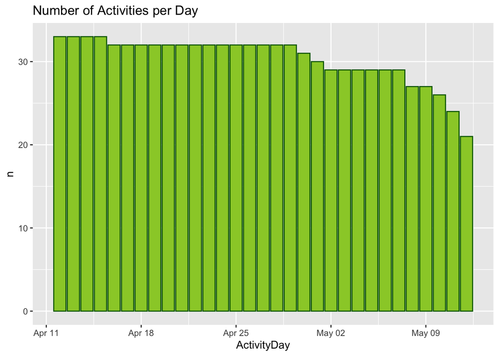

```r
#plot number of activities per day
new_daily_data%>%
  count(ActivityDay, sort=TRUE) %>%
  ggplot()+geom_col(mapping=aes(x=ActivityDay,y=n),fill="yellowgreen",color="darkgreen")+labs(title= "Number of Activities per Day")
```

```r
#The graph shows us that at least 12 people have missed an activity throughout the 31 days of this study. It also shows us that users are less dedicated as time goes on. Lets see how many people have gone without their fitbit assuming that 1440 sedentary minutes is equal to 24 sedentary hours.
fitbit_off <- new_daily_data %>%
  filter(SedentaryMinutes == 1440) %>%
  group_by(Id) %>%
  summarise(count = n()) %>%
  print()
```

```
## # A tibble: 17 × 2
##            Id count
##         <dbl> <int>
##  1 1503960366     1
##  2 1844505072     9
##  3 1927972279    13
##  4 4020332650    14
##  5 4057192912     1
##  6 4319703577     1
##  7 4388161847     1
##  8 4702921684     1
##  9 5577150313     2
## 10 6117666160     5
## 11 6290855005     4
## 12 6775888955     9
## 13 7007744171     1
## 14 7086361926     1
## 15 8253242879     1
## 16 8583815059     6
## 17 8792009665     9
```

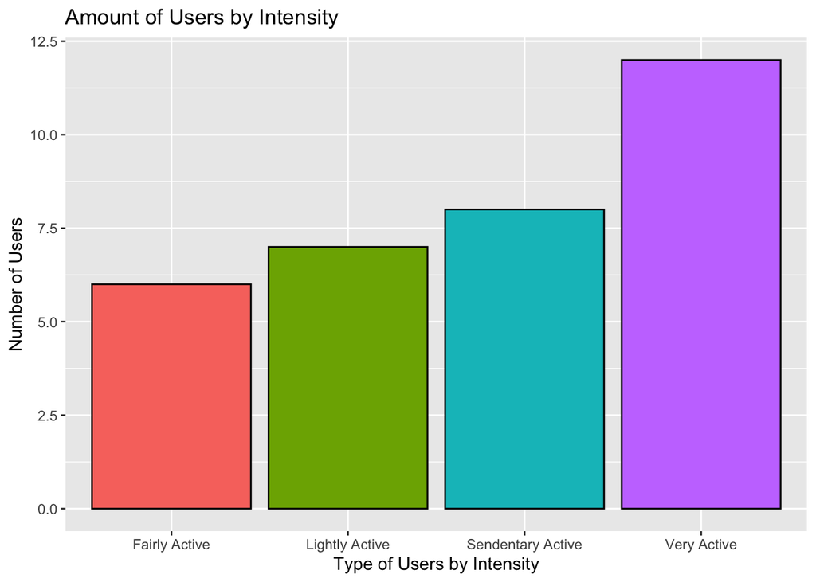

```r
#The output shows us that 17 users went at LEAST one day without using their fitbit. We want to see at which intensities our users are active while accounting for the number of users who had their fitbit off but still counted as Sedentary Active and skewing our data.
user_activity <- new_daily_data %>%
  filter(SedentaryMinutes != 1440) %>%
  group_by(Id) %>%
  summarize(total_very_active_mins = sum(VeryActiveMinutes),
            total_fairly_active_mins = sum(FairlyActiveMinutes),
            total_lightly_active_mins = sum(LightlyActiveMinutes),
            total_sendentary_mins = sum(SedentaryMinutes),
            total_mins = sum(VeryActiveMinutes, FairlyActiveMinutes, LightlyActiveMinutes, SedentaryMinutes),
            percent_very_active = (total_very_active_mins/total_mins)*100,
            percent_fairly_active = (total_fairly_active_mins/total_mins)*100,
            percent_lightly_active = (total_lightly_active_mins/total_mins)*100,
            percent_sendentary_active = (total_sendentary_mins/total_mins)*100) # Calculate percentages of minutes by intensity
user_activity <- user_activity %>%
  mutate(intensity =
           case_when(percent_very_active > mean(percent_very_active) ~ "Very Active",
                     percent_fairly_active > mean(percent_fairly_active) ~ "Fairly Active",
                     percent_lightly_active > mean(percent_lightly_active) ~ "Lightly Active",
                     percent_sendentary_active > mean(percent_sendentary_active) ~ "Sendentary Active"))
ds_activity <- user_activity %>%
  group_by(intensity) %>%
  summarise(count = n())
ggplot(ds_activity, aes(x = intensity, y = count, fill = intensity)) +
    geom_histogram(stat = "identity", color= "black") +
  ylab("Number of Users") +
  xlab("Type of Users by Intensity") +
  labs(title = "Amount of Users by Intensity") +
  theme(legend.position = "none")
```

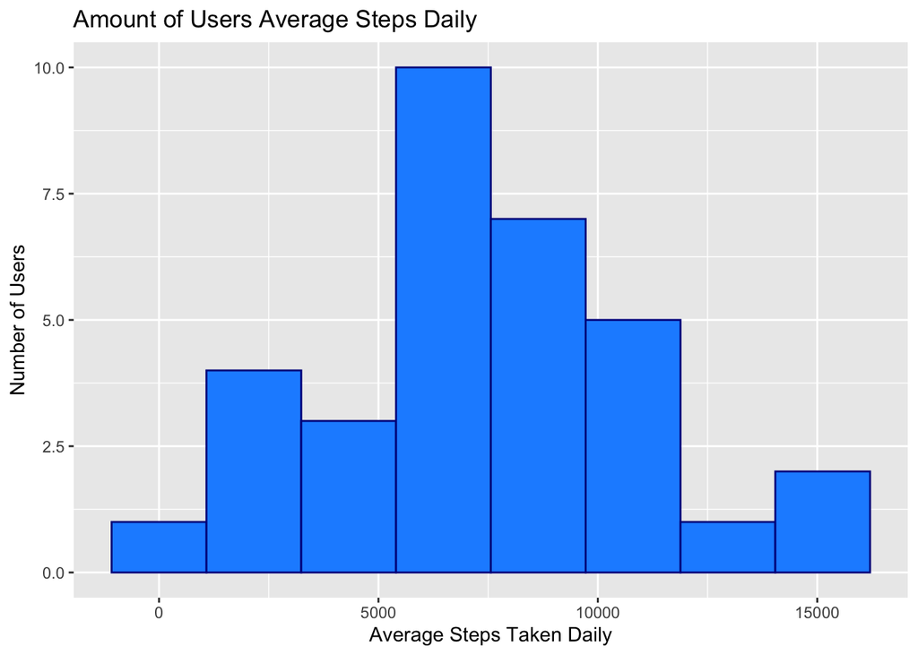

```r
#The graph shows us that 'Very Active' accounts for the highest number of users. Let's see how active our users are by checking total average steps per day.
new_daily_steps <- new_daily_data %>%
  group_by(Id) %>%
  summarise(avg_daily_steps = mean(TotalSteps))
ggplot(new_daily_steps, aes(x = avg_daily_steps)) +
  geom_histogram(bins = 8, fill = "dodgerblue", color = "blue4") +
  ylab("Number of Users") +
  xlab("Average Steps Taken Daily") +
  labs(title = "Amount of Users Average Steps Daily")
```

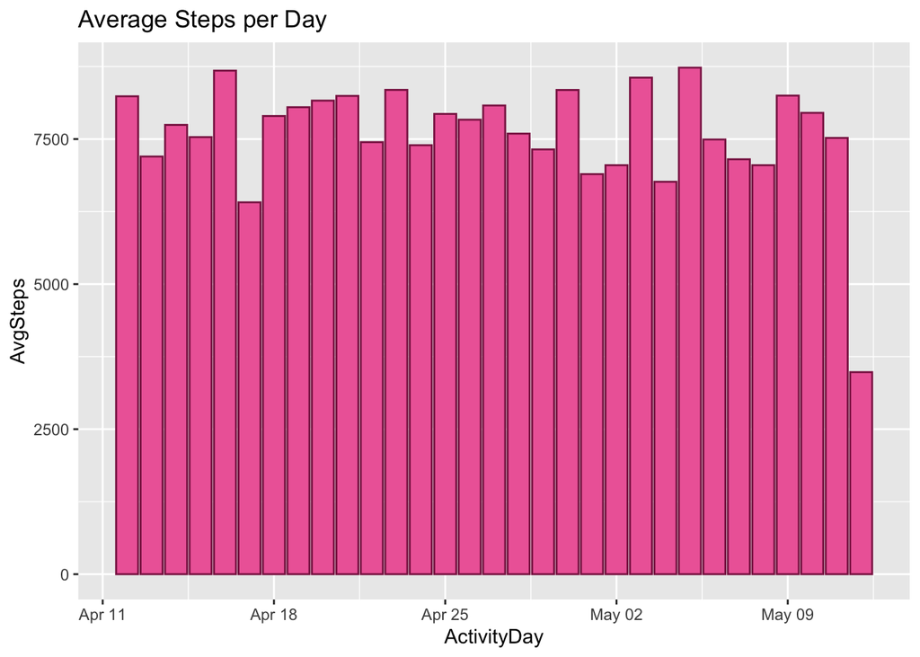

```r
#avg. steps per day
new_daily_data%>%
  group_by(ActivityDay) %>%
  summarise_at(vars(TotalSteps), list(AvgSteps = mean))%>%
  ggplot()+geom_col(mapping = aes(x=ActivityDay, y=AvgSteps),fill="hotpink2", color="violetred4")+ labs(title="Average Steps per Day")
```

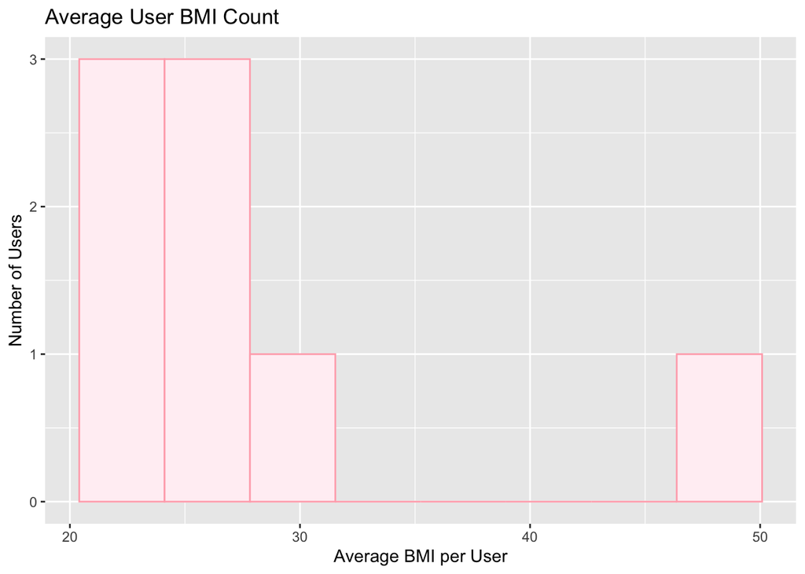

```r
#Users tend to take 5,000 to 10,000 steps daily on average. As we see in the second graph, this stays pretty consistent over time as well. This is not a high number since the CDC recommends that a person takes 10,000 steps per day. This makes sense since most users probably purchased a Fitbit with the desire to become more active. Let's check with the information that we have, how fit the users are.

body_weight <- new_weight_log %>%
  group_by(Id) %>%
  summarise(avg_bmi = mean(BMI))
ggplot(body_weight, aes(x =avg_bmi)) +
  geom_histogram(bins = 8, fill = "lavenderblush", color = "lightpink1") +
  ylab("Number of Users") +
  xlab("Average BMI per User") +
  labs(title = "Average User BMI Count")
```

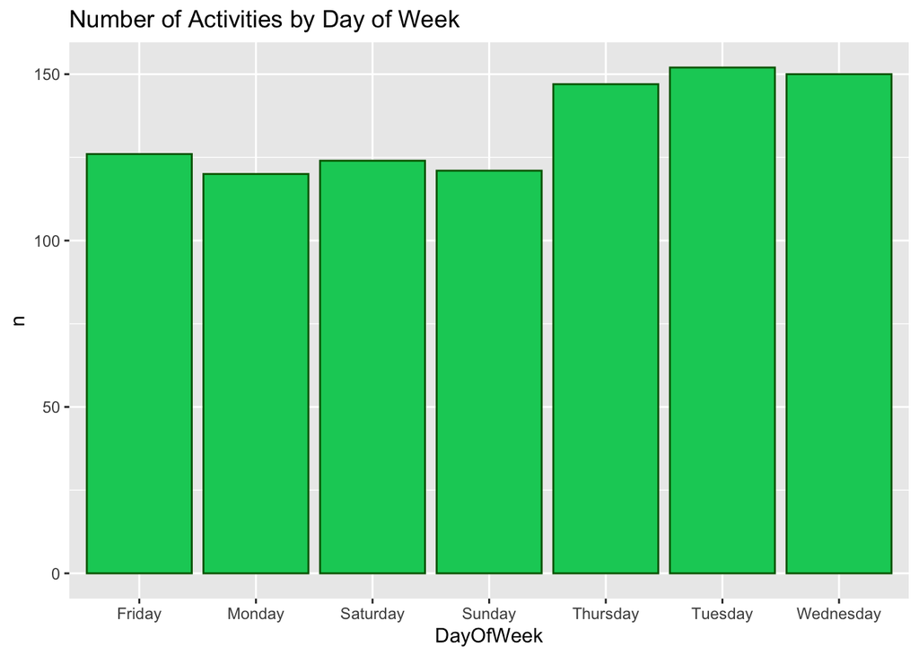

```r
#Though only 8 people logged their weights, 5 of those 8 fall within a BMI higher than 25 which, according to the CDC, is considered overweight. One person has a BMI over 30 which is considered overweight. Clearly, these fitbit users have the desire to become more fit.

#most active days of the week
new_daily_data$DayOfWeek<-weekdays(new_daily_data$ActivityDay)
new_daily_data%>%
  count(DayOfWeek,sort=TRUE)%>%
  ggplot()+geom_col(mapping= aes(x=DayOfWeek, y=n),fill="springgreen3" ,color="darkgreen")+labs(title="Number of Activities by Day of Week")
```

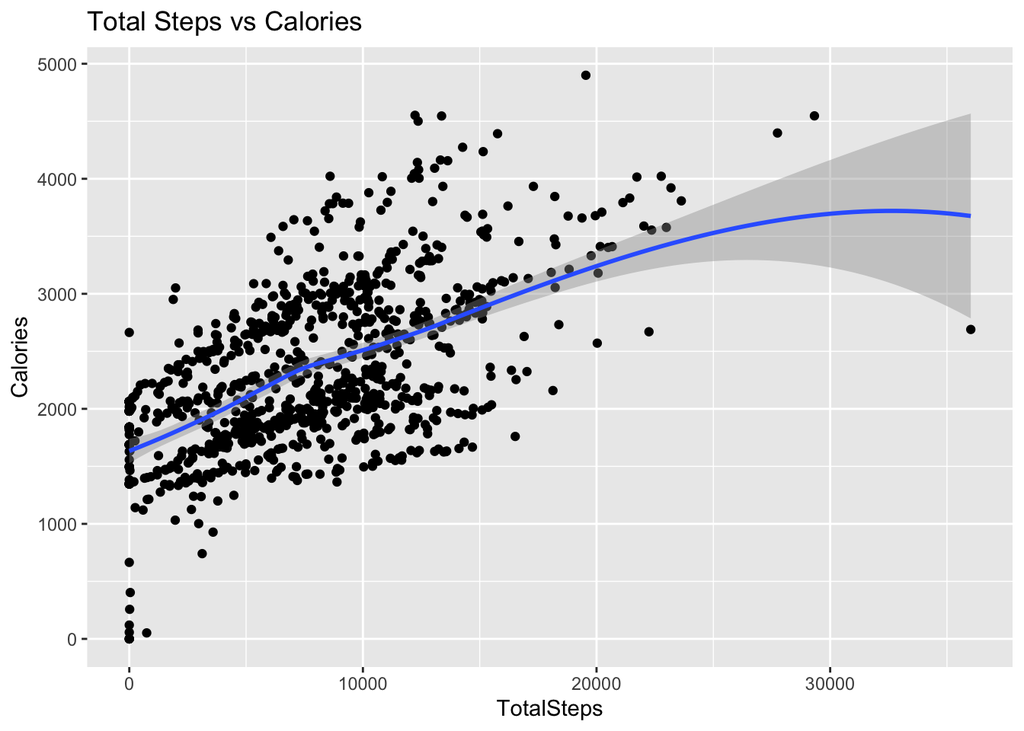

```r
#Tuesday, Wednesday and Thursday are the days of the week with the most activity. The graph shows that people are less active on the weekends.

#whats the relationship between steps and calories
ggplot(data=new_daily_data, aes(x=TotalSteps, y=Calories))+geom_point()+
geom_smooth() + labs(title="Total Steps vs Calories")
```

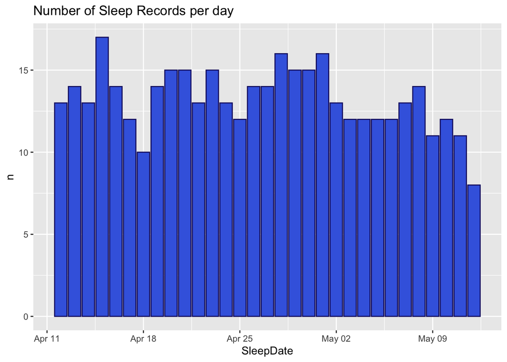

```r
#we see a positive correlation between total steps and calories. The more active they are, the more calories they are burning.

#how many users logged their sleep per day
new_sleep_day%>%
  count(SleepDate, sort=TRUE) %>%
  ggplot()+geom_col(aes(x=SleepDate,y=n),fill="royalblue", color="midnightblue")+labs(title= "Number of Sleep Records per day")
```

```r
#We can see that their are sudden drops in sleep records within the week. These days fall on Mondays. Not only do Mondays account for the lowest activity but also lowest sleep records.

skim(new_sleep_day)
```

Data summary

| Name | new_sleep_day |
| --- | --- |
| Number of rows | 410 |
| Number of columns | 6 |
| _______________________ |  |
| Column type frequency: |  |
| Date | 1 |
| difftime | 1 |
| numeric | 4 |
| ________________________ |  |
| Group variables | None |

**Variable type: Date**

| skim_variable | n_missing | complete_rate | min | max | median | n_unique |
| --- | --- | --- | --- | --- | --- | --- |
| SleepDate | 0 | 1 | 2016-04-12 | 2016-05-12 | 2016-04-27 | 31 |

**Variable type: difftime**

| skim_variable | n_missing | complete_rate | min | max | median | n_unique |
| --- | --- | --- | --- | --- | --- | --- |
| SleepTime | 0 | 1 | 0 secs | 0 secs | 0 secs | 1 |

**Variable type: numeric**

| skim_variable | n_missing | complete_rate | mean | sd | p0 | p25 | p50 | p75 | p100 | hist |
| --- | --- | --- | --- | --- | --- | --- | --- | --- | --- | --- |
| Id | 0 | 1 | 4.994963e+09 | 2.060863e+09 | 1503960366 | 3.977334e+09 | 4702921684.0 | 6962181067 | 8792009665 | ▆▆▇▅▃ |
| TotalSleepRecords | 0 | 1 | 1.120000e+00 | 3.500000e-01 | 1 | 1.000000e+00 | 1.0 | 1 | 3 | ▇▁▁▁▁ |
| TotalMinutesAsleep | 0 | 1 | 4.191700e+02 | 1.186400e+02 | 58 | 3.610000e+02 | 432.5 | 490 | 796 | ▁▂▇▃▁ |
| TotalTimeInBed | 0 | 1 | 4.584800e+02 | 1.274600e+02 | 61 | 4.037500e+02 | 463.0 | 526 | 961 | ▁▃▇▁▁ |

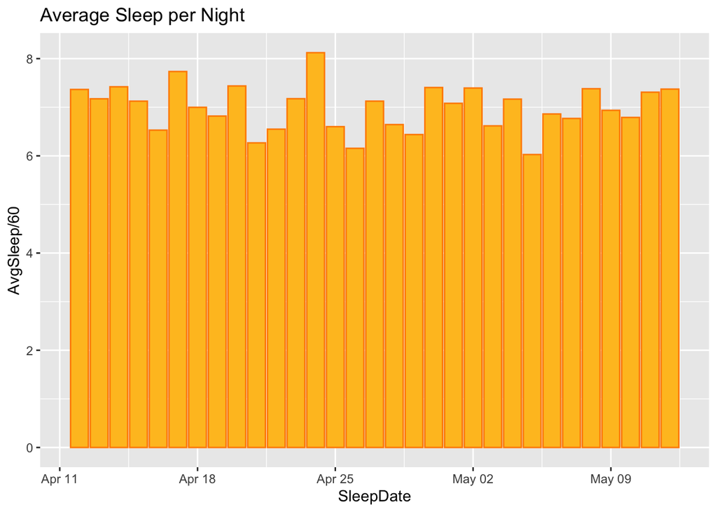

```r
#The average TotalMinutesAsleep equates to about 7 hours a night.

#average sleep
new_sleep_day%>%
  group_by(SleepDate) %>%
  summarise_at(vars(TotalMinutesAsleep), list(AvgSleep = mean))%>%
  ggplot()+geom_col(mapping = aes(x=SleepDate, y=AvgSleep/60),fill="goldenrod1", color="darkorange")+ labs(title="Average Sleep per Night")
```

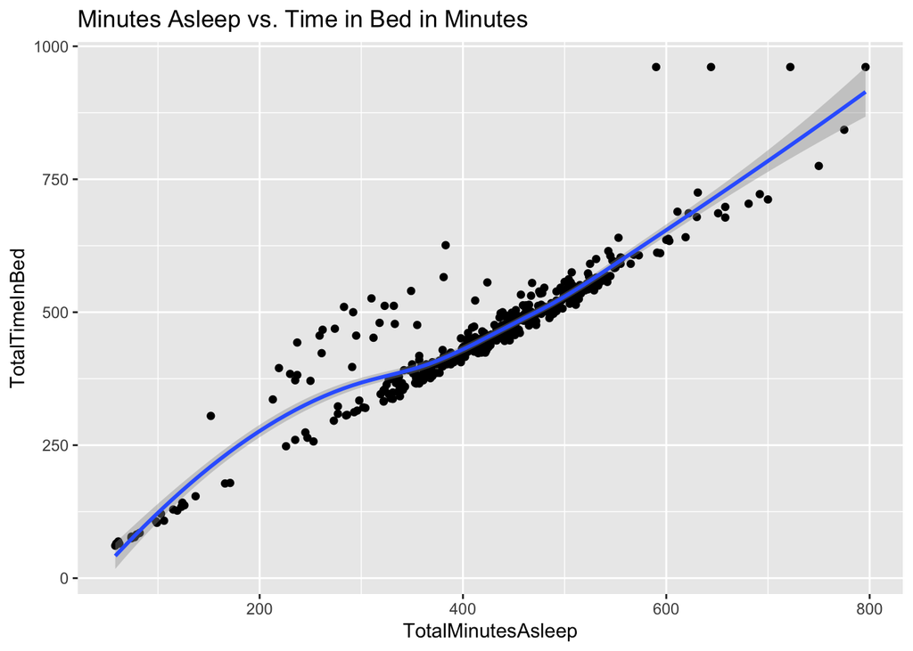

```r
#CDC recommends at least 7 hours of sleep per night for those over the age of 18. The younger you are, the more sleep is recommended.

##relationship between minutes asleep and time in bed
ggplot(data=new_sleep_day, aes(x=TotalMinutesAsleep, y=TotalTimeInBed))+ geom_point()+
geom_smooth()+labs(title="Minutes Asleep vs. Time in Bed in Minutes")
```

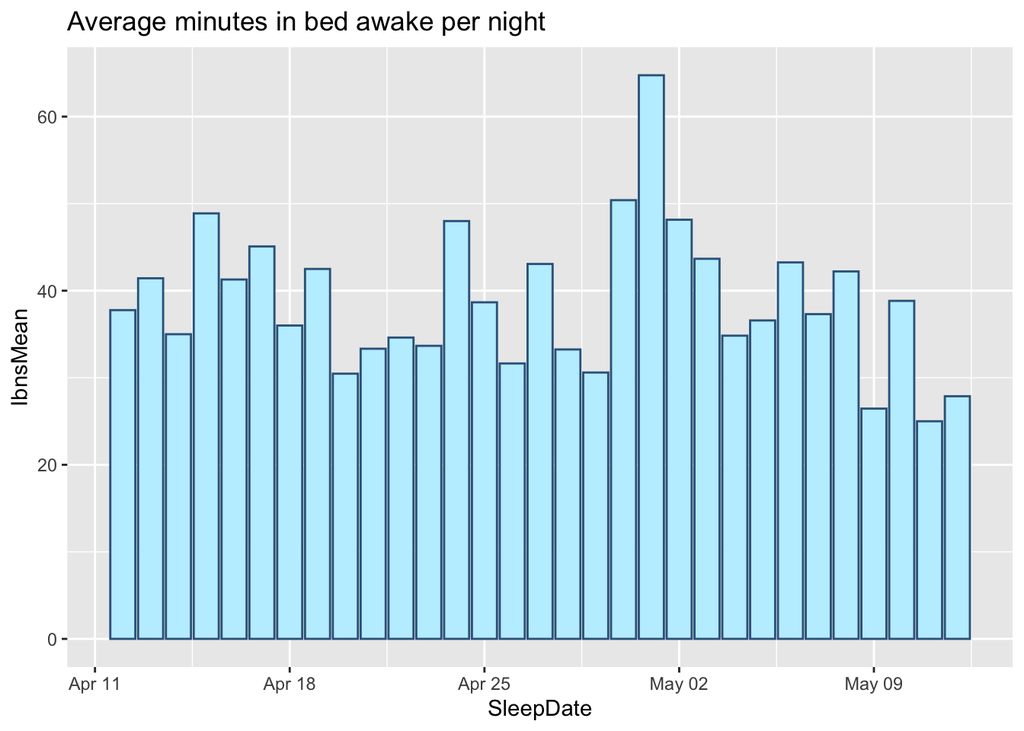

```r
#As expected, there is an almost completely linear trend between minutes asleep and time in bed. To help users improve their sleep schedules, the company should consider using notification to go to sleep.

#average time in bed but awake
new_sleep_day%>%
  mutate(InBedNoSleep=TotalTimeInBed-TotalMinutesAsleep)%>%
  group_by(SleepDate) %>%
  summarise_at(vars(InBedNoSleep), list(IbnsMean = mean))%>%
  ggplot()+geom_col(mapping = aes(x=SleepDate, y=IbnsMean),fill="lightblue1", color="steelblue4")+ labs(title="Average minutes in bed awake per night")
```

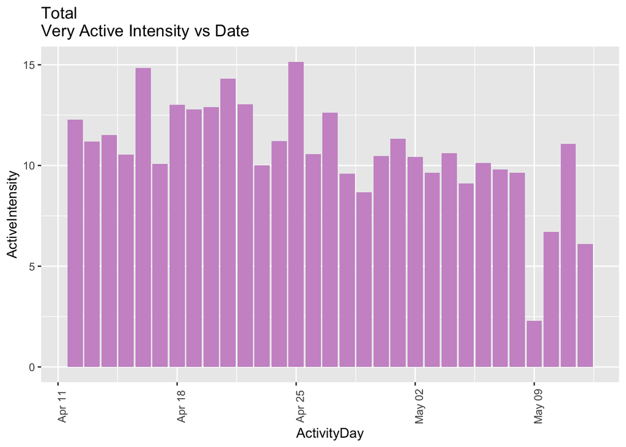

```r
#on average, it took the participants 40 minutes to fall asleep after laying in bed. Going off the previous idea, the company should consider setting the notification to go to sleep to 40 minutes before the user plans on actually sleeping.

#Lets see if being active helps or hurts when trying to get a good nights sleep.
##intensities data
new_daily_data$ActiveIntensity <- (daily_intensities$VeryActiveMinutes/60)
ggplot(data=new_daily_data, aes(x=ActivityDay, y=ActiveIntensity))+ geom_histogram(stat= "identity", fill="plum3")+ theme(axis.text.x = element_text(angle=90))+labs(title="Total
Very Active Intensity vs Date")
```

```r
#When comparing the two graphs, we can see that there is no visible correlation between intensity and time in bed awake.
```

#Recap of my findings *As time goes by, users tend to be less active on their Fitbits* though only 8 people logged their weights, 5 of those 8 fall within a BMI higher than 25 which, according to the CDC, is considered overweight. One person has a BMI over 30 which is considered obese. *‘Very Active’ accounts for the highest number of users* participants tend to take 5000 to 10000 steps daily on average *Tuesday, Wednesday and Thursday are the days of the week with the most activity* people are less active on the weekends *positive correlation between total steps and calories. The more active they are, the more calories they are burning.* Not only do Mondays account for the lowest activity but also lowest sleep records *there is an almost completely linear trend between minutes asleep and time in bed* on average, it took the participants 40 minutes to fall asleep after laying in bed *there is no visible correlation between intensity and time in bed awake or sleep

##Recommendations Of all of their products, Bellabeat’s smart watch device, Time, is the most comparable to a Fitbit. Both devices are worn on your wrist to track personalized activity and sleep. I recommend that the marketing team focuses on promoting the categories with high user activity, which are intensities, steps, and sleep. We know that only 8 of 33 users were tracking their weight, showing that weight loss might not be a priority for them. Instead of being marketed as a device that assists weight-loss, Bellabeat should emphasize body positivity and promote a healthy lifestyle. We see that there is a large discrepancy between how many steps your taking/how much sleep your getting and the day of the week. By targeting women who live sedentary lifestyles but want to become more active, we can use goal-oriented reminders to take 10,000 steps per day and sleep at least 8 hours a night to improve or maintain their current health habits. Since we found that it takes user an average of 40 minutes to fall asleep, by pushing 8 hours of sleep we are making sure that users will get the CDC recommended 7 hours. Especially since user activity decreased over time, regular reminders can help keep activity consistent. Since our targeted market is specifically geared towards women, our Time device should really emphasize the fact that this product allows you to do all the things a Fitbit can and more. The Time watch is capable of tracking your stress, where you are in your cycle, as well as an option for women who are pregnant. The discreet design also makes it perfect to keep on all day long, including work hours, unlike the Fitbit which may look unprofessional.